# Cryptowatch Data Visualizations

## Part 1: Working with code

```python
import numpy as np

import matplotlib.pyplot as plt
%matplotlib inline
```

numpy the most popular Python library for array manipulation and numeric computing matplotlib the most popular visualization library in the Python ecosystem.

```python
x = np.linspace(0, 10, 500)
y = np.cumsum(np.random.randn(500, 6), 0)
```

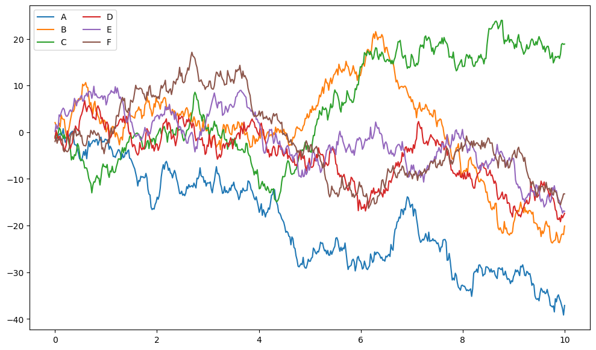

```python
plt.figure(figsize=(12, 7))
plt.plot(x, y)
plt.legend('ABCDEF', ncol=2, loc='upper left')
```

# Part 2: Interacting with data¶

Notebooks.ai and Jupyter Lab make it really simple to intereact with files in your local storage. These files are securely stored in the cloud and you can access them from anywhere in the world.

To show you the full potential of Notebooks.ai, we're going to pull cryptocurrencies prices from a public API and download them as Excel files, pretty fancy . I need to import two libraries first: requests (to pull data from the web) and pandas to process it.

```python
import  requests
import pandas as pd
```

I have a predefined function that simplifies the process of importing data from Cryptowatch (for reference, check their docs).

```python
def get_historic_price(symbol, exchange='bitfinex', after='2018-09-01'):
    url = 'https://api.cryptowat.ch/markets/{exchange}/{symbol}usd/ohlc'.format(
        symbol=symbol, exchange=exchange)
    resp = requests.get(url, params={
        'periods': '3600',
        'after': str(int(pd.Timestamp(after).timestamp()))
    })
    resp.raise_for_status()
    data = resp.json()
    df = pd.DataFrame(data['result']['3600'], columns=[
        'CloseTime', 'OpenPrice', 'HighPrice', 'LowPrice', 'ClosePrice', 'Volume', 'NA'
    ])
    df['CloseTime'] = pd.to_datetime(df['CloseTime'], unit='s')
    df.set_index('CloseTime', inplace=True)
    return df
```

I will now pull data from Bitcoin and Ether, two of the most popular cryptocurrencies, for the last 7 days:

```python
last_week = (pd.Timestamp.now() - pd.offsets.Day(7))
last_week
```

```
Timestamp('2023-08-30 12:02:01.394501')
```

```python
btc = get_historic_price('btc', 'bitstamp', after=last_week)
```

```python
eth = get_historic_price('eth', 'bitstamp', after=last_week)
```

# Bitcoin:

```python
btc.head()
```

| CloseTime | OpenPrice | HighPrice | LowPrice | ClosePrice | Volume | NA |
| --- | --- | --- | --- | --- | --- | --- |
| 2023-08-30 13:00:00 | 27337 | 27416 | 27295 | 27350 | 123.875569 | 3.389334e+06 |
| 2023-08-30 14:00:00 | 27344 | 27452 | 27187 | 27365 | 234.699017 | 6.413749e+06 |
| 2023-08-30 15:00:00 | 27370 | 27418 | 27019 | 27108 | 213.444789 | 5.810830e+06 |
| 2023-08-30 16:00:00 | 27113 | 27284 | 27006 | 27204 | 295.054951 | 8.013086e+06 |
| 2023-08-30 17:00:00 | 27197 | 27212 | 27045 | 27152 | 127.199367 | 3.447892e+06 |

```python
import datetime
```

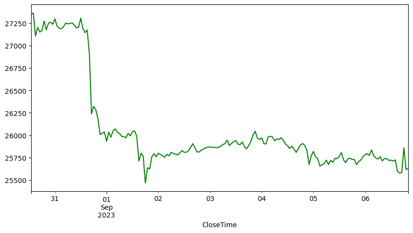

```python
btc['ClosePrice'].plot(figsize=(10, 5),color='green')
```

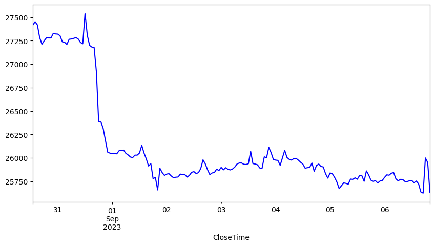

```python
btc['HighPrice'].plot(figsize=(10,5),color='blue')
```

# Ether:

```python
eth.head()
```

| CloseTime | OpenPrice | HighPrice | LowPrice | ClosePrice | Volume | NA |
| --- | --- | --- | --- | --- | --- | --- |
| 2023-08-30 13:00:00 | 1715.9 | 1720.4 | 1713.2 | 1717.5 | 129.136666 | 2.217100e+05 |
| 2023-08-30 14:00:00 | 1717.3 | 1722.1 | 1705.0 | 1717.5 | 340.286165 | 5.831756e+05 |
| 2023-08-30 15:00:00 | 1718.3 | 1719.8 | 1696.8 | 1703.5 | 915.503452 | 1.561867e+06 |
| 2023-08-30 16:00:00 | 1702.6 | 1708.2 | 1698.1 | 1703.3 | 205.466617 | 3.499495e+05 |
| 2023-08-30 17:00:00 | 1702.8 | 1704.3 | 1696.5 | 1700.3 | 202.990096 | 3.451329e+05 |

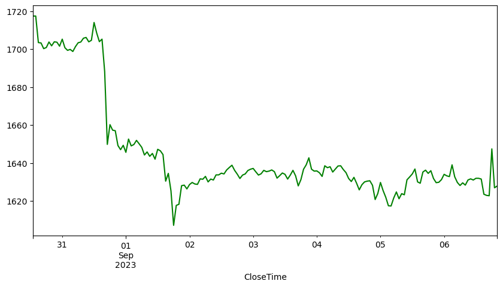

```python
eth['ClosePrice'].plot(figsize=(10, 5),color='green')
```

As you can see, we're able to pull data from the internet with just a few lines, create a DataFrame and plot it all within Jupyter Lab.

# Bonus: Dynamic plots with Bokeh

We've also included Bokeh as part of this main distribution. Bokeh is a plotting library that generates interactive plots, that can be manipulated right within your browser.

We first need to import the libraries:

```python
from bokeh.plotting import figure, output_file, show
from bokeh.io import output_notebook
```

```python
output_notebook()
```

Loading BokehJS ...

```python
p1 = figure(x_axis_type="datetime", title="Crypto Prices", width=800)
p1.grid.grid_line_alpha=0.3
p1.xaxis.axis_label = 'Date'
p1.yaxis.axis_label = 'Price'
p1.line(btc.index,btc['ClosePrice'], color='#f2a900', legend_label='Bitcoin')
#p1.line(eth.index, eth['ClosePrice'], color='#A6CEE3', legend='Ether')
p1.legend.location = "top_left"
show(p1)
```

[output not shown]

# Part 3: Exporting to Excel

We're now ready to generate an Excel file from the downloaded prices. Working with Excel and other formats (like CSV or JSON) is extremely simple in Jupyter Lab (thanks to pandas and Python). Our first step will be to create an "Excel writer", a component from the pandas package:

```python
writer = pd.ExcelWriter('cryptos.xlsx')
```

We'll now write both our Bitcoin and Ether data as separate sheets:

```python
btc.to_excel(writer, sheet_name='Bitcoin')
```

```python
eth.to_excel(writer, sheet_name='Ether')
```

save the files

```python
writer.save()
```

## Help for this File execution , emails me turatsinzecmu2020@gmail.com